# InferenceAssignment

NithaDuff

7/23/2020

```r
library(dplyr)
```

```r
library(ggplot2)
```

## Central Limit Theorem

n this project you will investigate the exponential distribution in R and compare it with the Central Limit Theorem. The exponential distribution can be simulated in R with rexp(n, lambda) where lambda is the rate parameter. The mean of exponential distribution is 1/lambda and the standard deviation is also 1/lambda. Set lambda = 0.2 for all of the simulations. You will investigate the distribution of averages of 40 exponentials. Note that you will need to do a thousand simulations.

```r
lambda <- 0.2
mean <- sd <-  1/lambda
n <- 40
nosim <- 1000
x <- rexp(n,lambda)
```

```r
samples <- matrix(sample(x,n*nosim,replace = T),nosim,n)
means <- apply(samples,1,mean)
vars <- apply(samples, 1, var)
```

```r
mu0 <- mean(means)
print(c(mean,mu0))
```

```
## [1] 5.000000 6.354399
```

```r
print(c(sd^2,mean(vars)))
```

```
## [1] 25.00000 38.90486
```

## Distribution of means

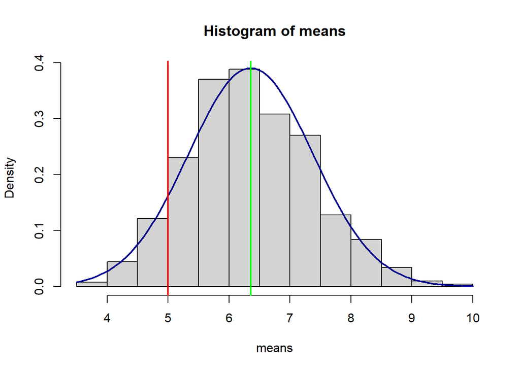

```r
hist(means, probability = TRUE)
curve(dnorm(x, mean=mean(means), sd=sd(means)), col="darkblue", lwd=2, add=TRUE, yaxt="n")
abline(v = mean, col = "red", lwd = 2)
abline(v = mean(means),col = "green", lwd = 2)
```

## Distribution of variance

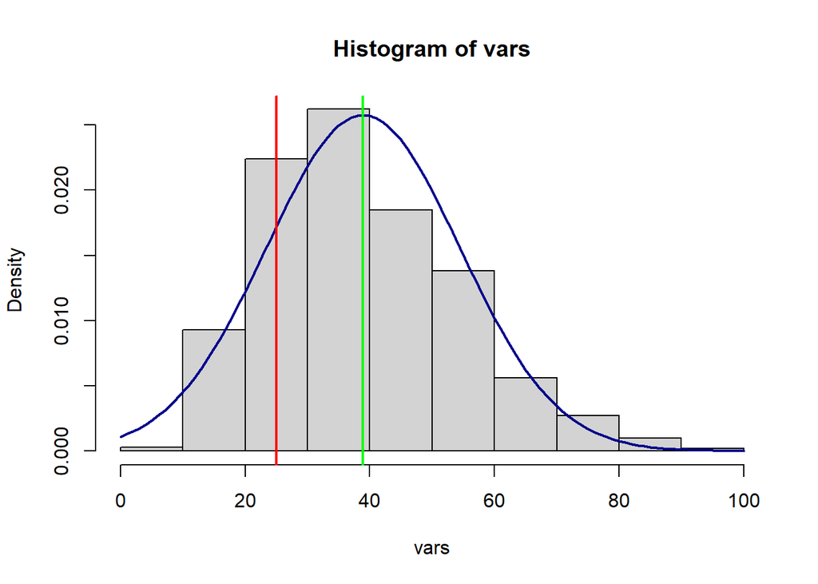

```r
hist(vars, probability = TRUE)
curve(dnorm(x, mean=mean(vars), sd=sd(vars)), col="darkblue", lwd=2, add=TRUE, yaxt="n")
abline(v = sd^2, col = "red", lwd = 2)
abline(v = mean(vars),col = "green", lwd = 2)
```

## ToothGrowth data analysis

Here we are analysing the data reported for the ToothGrowth of a sample of 60 guinea pigs with varying dosage and 2 alternative supplements. The data looks like the following table.

```r
data("ToothGrowth")
head(ToothGrowth)
```

```
##    len supp dose
## 1  4.2   VC  0.5
## 2 11.5   VC  0.5
## 3  7.3   VC  0.5
## 4  5.8   VC  0.5
## 5  6.4   VC  0.5
## 6 10.0   VC  0.5
```

```r
summary(ToothGrowth)
```

```
##       len        supp         dose
##  Min.   : 4.20   OJ:30   Min.   :0.500
##  1st Qu.:13.07   VC:30   1st Qu.:0.500
##  Median :19.25           Median :1.000
##  Mean   :18.81           Mean   :1.167
##  3rd Qu.:25.27           3rd Qu.:2.000
##  Max.   :33.90           Max.   :2.000
```

As seen above the data frame has 3 columns each containing the length(of tooth), supplement group, dosage given. There are 2 supplements and 3 variant dosages of each supplement. This is equally divided between 60 guinea pigs.

```r
t.test(len ~ I(relevel(supp,2)), paired = FALSE, data = ToothGrowth)
```

```
##
##  Welch Two Sample t-test
##
## data:  len by I(relevel(supp, 2))
## t = -1.9153, df = 55.309, p-value = 0.06063
## alternative hypothesis: true difference in means is not equal to 0
## 95 percent confidence interval:
##  -7.5710156  0.1710156
## sample estimates:
## mean in group VC mean in group OJ
##         16.96333         20.66333
```

from the above data, we can analyse the group means, the confidence interval of the entire data and so on.

## ToothGrowth data Visualisation

```r
tooth_mns <- ToothGrowth %>% group_by(supp,dose)  %>% summarise(mean = mean(len)) %>% print()
```

```
## # A tibble: 6 x 3
## # Groups:   supp [2]
##   supp   dose  mean
##   <fct> <dbl> <dbl>
## 1 OJ      0.5 13.2
## 2 OJ      1   22.7
## 3 OJ      2   26.1
## 4 VC      0.5  7.98
## 5 VC      1   16.8
## 6 VC      2   26.1
```

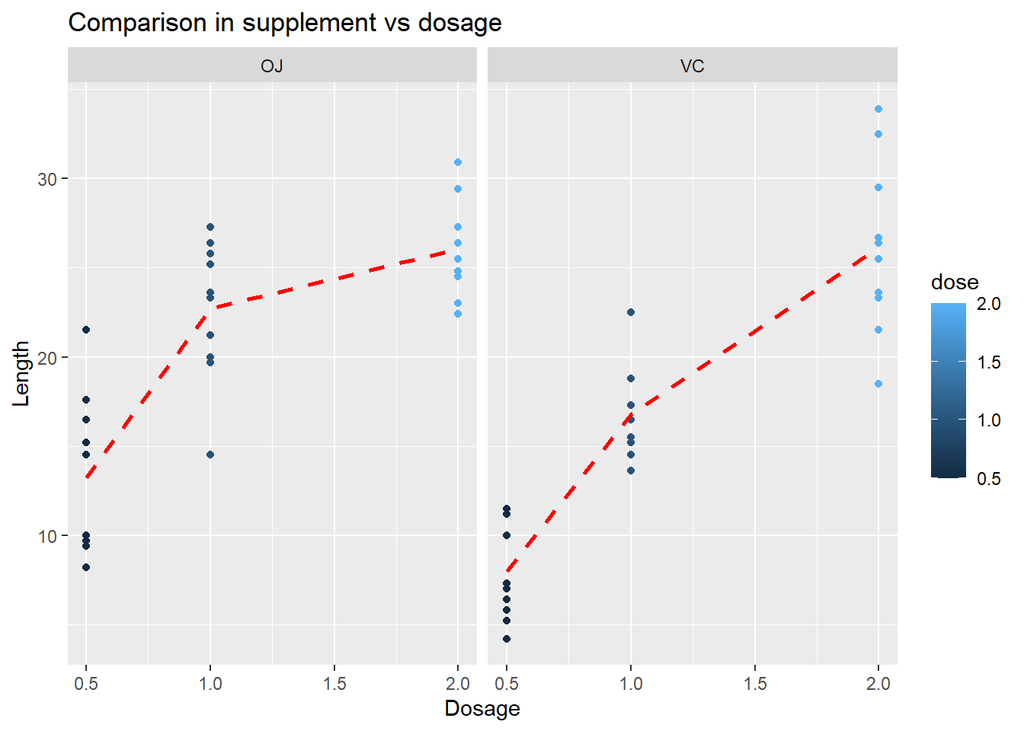

```r
g <- ggplot(ToothGrowth, aes(x = dose, y = len, colour = dose, group = supp))
g <- g + geom_point()
g <- g + geom_line(tooth_mns, mapping = aes(x = dose,y = mean),linetype = 2, size = 1, color = "red")
g <- g + facet_grid(. ~ supp) + labs(x = "Dosage", y = "Length" , title = "Comparison in supplement vs dosage")
print(g)
```

The plot here shows the comparison between the 2 supplement types with respect to the level of dosage. From the plot we can infer that in either case of supplement the dosage with value 2.0 has a higher mean. Though the difference in means between 1.0 and 2.0 in case of supplement OJ is very less. Hence the increase in dosage has not made much impact. Whereas in case of supplement VC, the dosage levels show a significant improvement in length.

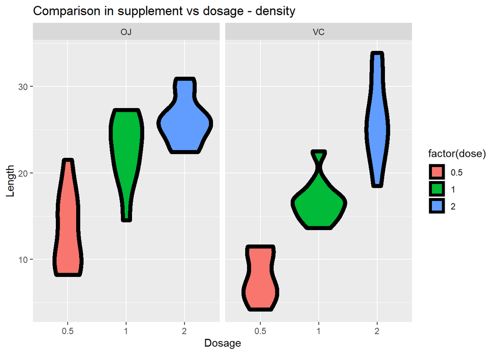

```r
g <- ggplot(ToothGrowth, aes(x = factor(dose), y = len, fill = factor(dose)))
g <- g + geom_violin(col = "black", size = 2)
g <- g + facet_grid(. ~ supp) + labs(x = "Dosage", y = "Length" , title = "Comparison in supplement vs dosage - density")
print(g)
```

The violin plots shows that the net effect dosage of VC with value 2.0 has a higher limit. Yet he results of supplement OJ has a comparatively steady outcome. with varying dosages.